December 15, 2016

Graphics in data analysis are useful for several tasks including:

- understand data properties
- find patterns in data
- communicate results

First thing you want to do, as usual, is to setup your working directory

```r
# dir.create("C:/Users/jac/Documents/GitHub/introduction_r_training/4_data_visualization") # put the path you prefer
setwd("C:/Users/jac/Documents/GitHub/introduction_r_training/4_data_visualization") # use same path used above
```

and load the packages you will need for this class (if you have not done so yet you will have to install them first)

```r
library(dplyr)
library(MASS)
library(rworldmap)
library(ggplot2)
library(RColorBrewer)
```

# **UNDERSTAND DATA PROPERTIES**

We will start with some exploratory graphics (quick and dirty) to summarize data and highlight broad features. This is useful to explore basic questions and hypothesis, suggest modeling strategies, etc.

```r
x <- rnorm(100)
y <- x + rnorm(100, mean=0.2, sd=2)
df <- data.frame(lab = LETTERS[1:7], g = rgamma(7, shape = 100))
```

plot() is a generic function to plot R objects. It is generic because it adapts to the input provided:

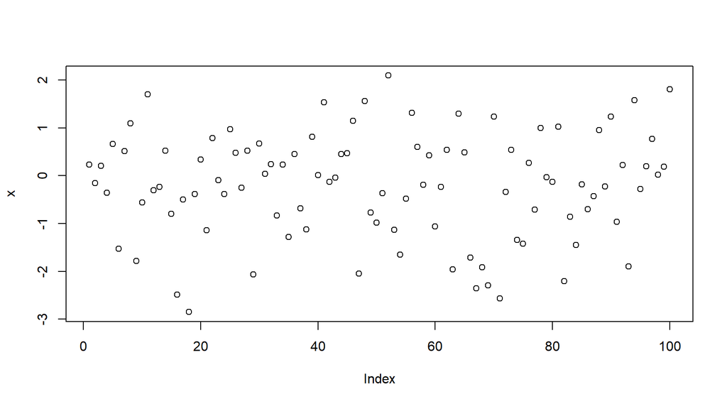

```r
plot(x) # values against integer index
```

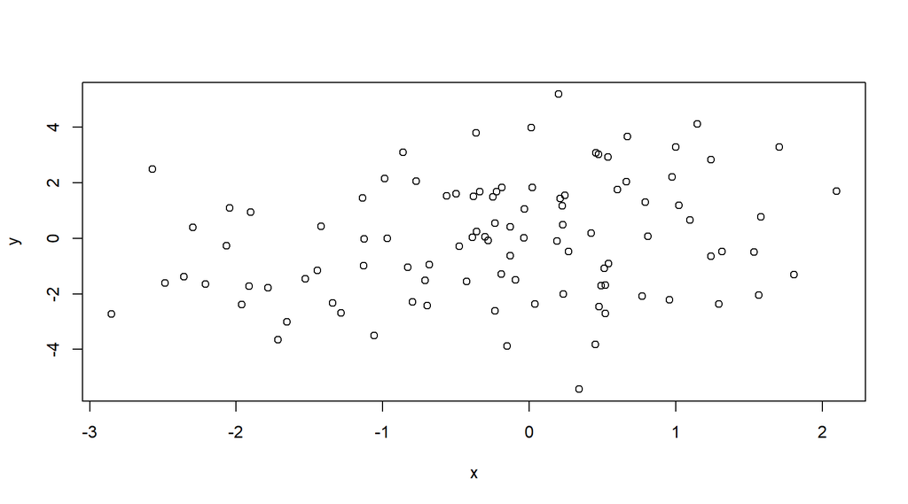

```r
plot(x, y) # scatterplot
```

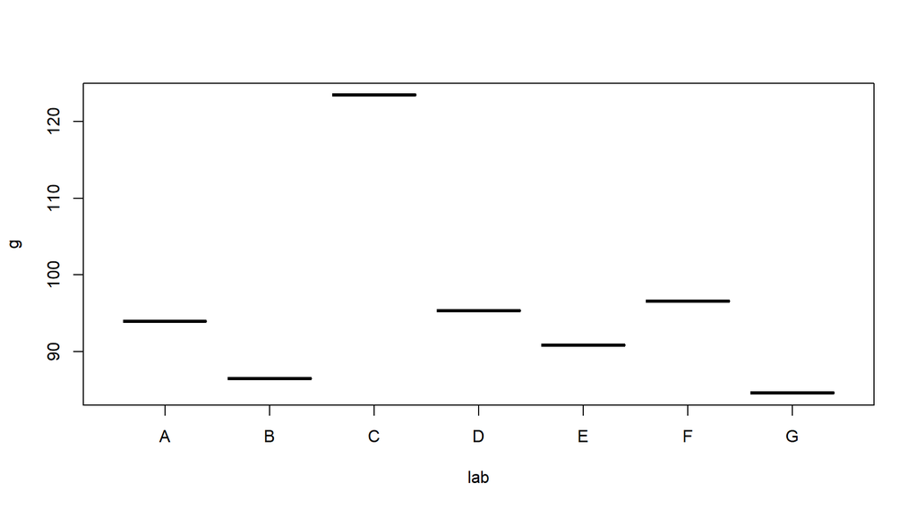

```r
plot(df) # barplot
```

Now let’s play with some insurance data. Read the data (copy the data PolicyPtf.csv in the working directory first)

```r
dt <- read.csv("../data/PolicyPtf.csv")
str(dt) # to have an idea of what kind of data you have read-in
```

```
## 'data.frame':    100021 obs. of  20 variables:
##  $ PolNum        : int  200114978 200114994 200115001 200115011 200115015 200115016 200115023 200115043 200115048 200115063 ...
##  $ CalYear       : int  2009 2009 2009 2009 2009 2009 2009 2009 2009 2009 ...
##  $ Gender        : Factor w/ 2 levels "Female","Male": 2 2 1 1 1 1 1 1 2 2 ...
##  $ Type_Car      : Factor w/ 6 levels "A","B","C","D",..: 3 5 5 3 4 4 3 2 5 4 ...
##  $ Category_Car  : Factor w/ 3 levels "Large","Medium",..: 1 1 1 2 1 3 3 2 2 2 ...
##  $ Occupation    : Factor w/ 5 levels "Employed","Housewife",..: 1 1 5 2 1 1 5 1 5 1 ...
##  $ Age           : int  25 20 42 21 33 26 20 29 31 35 ...
##  $ Group_Car     : int  18 11 11 5 12 13 7 3 3 7 ...
##  $ Bonus         : int  90 30 150 0 30 40 80 -20 -40 120 ...
##  $ Poldur        : int  3 2 0 0 10 7 13 12 10 1 ...
##  $ Value_Car     : int  15080 22370 39650 12600 9065 27335 7710 8965 21030 19995 ...
##  $ Adind         : int  0 1 0 1 0 1 0 0 1 1 ...
##  $ Sub_Region    : Factor w/ 471 levels "L1","L10","L100",..: 78 216 280 93 179 166 321 336 375 274 ...
##  $ Region        : Factor w/ 10 levels "L","M","N","O",..: 1 4 6 1 3 3 6 7 7 6 ...
##  $ Density_Region: num  72 39.6 169.5 58.9 109.6 ...
##  $ Exposure      : num  1 1 1 1 1 ...
##  $ mclaim        : int  1 1 2 1 2 1 1 1 1 1 ...
##  $ bclaim        : int  0 0 0 0 0 0 0 0 0 0 ...
##  $ mcost         : num  0 0 0 0 0 0 0 0 0 0 ...
##  $ bcost         : num  0 0 0 0 0 0 0 0 0 0 ...
```

```r
summary(dt) # to obtain a summary of data
```

```
##      PolNum             CalYear        Gender      Type_Car  Category_Car           Occupation
##  Min.   :200114871   Min.   :2009   Female:36578   A:27760   Large :35130   Employed     :31150
##  1st Qu.:200139855   1st Qu.:2009   Male  :63443   B:22090   Medium:36644   Housewife    :20010
##  Median :200164860   Median :2009                  C:13862   Small :28247   Retired      :13167
##  Mean   :200200320   Mean   :2009                  D:19597                  Self-employed:20372
##  3rd Qu.:200260800   3rd Qu.:2010                  E:11171                  Unemployed   :15322
##  Max.   :200285805   Max.   :2010                  F: 5541
##
##       Age          Group_Car         Bonus             Poldur         Value_Car         Adind
##  Min.   :18.00   Min.   : 1.00   Min.   :-50.000   Min.   : 0.000   Min.   : 1000   Min.   :0.0000
##  1st Qu.:30.00   1st Qu.: 7.00   1st Qu.:-40.000   1st Qu.: 1.000   1st Qu.: 8380   1st Qu.:0.0000
##  Median :40.00   Median :11.00   Median :-30.000   Median : 4.000   Median :14610   Median :1.0000
##  Mean   :41.12   Mean   :10.69   Mean   : -6.922   Mean   : 5.471   Mean   :16455   Mean   :0.5121
##  3rd Qu.:51.00   3rd Qu.:14.00   3rd Qu.: 10.000   3rd Qu.: 9.000   3rd Qu.:22575   3rd Qu.:1.0000
##  Max.   :75.00   Max.   :20.00   Max.   :150.000   Max.   :15.000   Max.   :49995   Max.   :1.0000
##
##    Sub_Region        Region      Density_Region      Exposure          mclaim           bclaim
##  Q29    :  431   L      :23733   Min.   : 14.38   Min.   :0.2493   Min.   :0.0000   Min.   :0.00000
##  Q24    :  427   Q      :22386   1st Qu.: 50.63   1st Qu.:0.9315   1st Qu.:0.0000   1st Qu.:0.00000
##  Q36    :  422   R      :15081   Median : 94.36   Median :1.0000   Median :0.0000   Median :0.00000
##  Q34    :  421   M      : 7597   Mean   :117.16   Mean   :0.8975   Mean   :0.1474   Mean   :0.04679
##  Q20    :  412   U      : 5364   3rd Qu.:174.64   3rd Qu.:1.0000   3rd Qu.:0.0000   3rd Qu.:0.00000
##  Q40    :  411   P      : 5259   Max.   :297.39   Max.   :1.0000   Max.   :7.0000   Max.   :3.00000
##  (Other):97497   (Other):20601
##      mcost             bcost
##  Min.   :    0.0   Min.   :    0.0
##  1st Qu.:    0.0   1st Qu.:    0.0
##  Median :    0.0   Median :    0.0
##  Mean   :  106.1   Mean   :  222.8
##  3rd Qu.:    0.0   3rd Qu.:    0.0
##  Max.   :12878.4   Max.   :69068.0
##
```

We’ve got 100.000 observations, 20 variables including

- temporal information: calendar year
- various information on the type of risk (policyholder gender, type car of vehicle insured, etc.)
- various risk information (number of material claims occurred in a given year, percentage of the year being exposed to the risk, etc.)